# Computer Assignment #4

## Ali Hamzehpour 810100129

## Machine Learning(Linear Regression and Classification)

### Problem Description

We are given a [dataset](https://geodacenter.github.io/data-and-lab/KingCounty-HouseSales2015/) that contains home sales' prices and their characteristics in King County, USA. We're asked to learn about dataset with visualization and statistical tools and preprocess the data to make it cleaner and better for Machine Learning tasks. Then, We have to perform Linear Regression and Classification methods on the data to predict the price of the houses.

## Exploratory Data Analysis

First I loaded the dataset and called some functions to get a general understanding of our data.

```python
import pandas as pd

data = pd.read_csv("house_data.csv")
```

```python
data.info()
```

```
<class 'pandas.core.frame.DataFrame'>
RangeIndex: 21613 entries, 0 to 21612
Data columns (total 27 columns):
 #   Column          Non-Null Count  Dtype
---  ------          --------------  -----
 0   Unnamed: 0      21613 non-null  int64
 1   Unnamed: 0.1    21613 non-null  int64
 2   Unnamed: 0.1.1  21613 non-null  int64
 3   id              21613 non-null  int64
 4   date            21613 non-null  object
 5   price           21613 non-null  float64
 6   bedrooms        21613 non-null  int64
 7   bathrooms       21613 non-null  float64
 8   sqft_living     18528 non-null  float64
 9   sqft_lot        21613 non-null  int64
```

[output cut: 19 more lines]

```python
data.head(10)
```

|  | Unnamed: 0 | Unnamed: 0.1 | Unnamed: 0.1.1 | id | date | price | bedrooms | bathrooms | sqft_living | sqft_lot | ... | yr_built | yr_renovated | zipcode | lat | long | sqft_living15 | sqft_lot15 | location | style | house_age |
| --- | --- | --- | --- | --- | --- | --- | --- | --- | --- | --- | --- | --- | --- | --- | --- | --- | --- | --- | --- | --- | --- |
| 0 | 0 | 0 | 0 | 7129300520 | 20141013T000000 | 221900.0 | 3 | 1.00 | 1180.0 | 5650 | ... | 1955.0 | 0 | 98178 | 47.5112 | -122.257 | 1340 | 5650 | Suburban | Contemporary | 67 |
| 1 | 1 | 1 | 1 | 6414100192 | 20141209T000000 | 538000.0 | 3 | 2.25 | 2570.0 | 7242 | ... | NaN | 1991 | 98125 | 47.7210 | -122.319 | 1690 | 7639 | Suburban | Ranch | 71 |
| 2 | 2 | 2 | 2 | 5631500400 | 20150225T000000 | 180000.0 | 2 | 1.00 | 770.0 | 10000 | ... | 1933.0 | 0 | 98028 | 47.7379 | -122.233 | 2720 | 8062 | Rural | Victorian | 89 |
| 3 | 3 | 3 | 3 | 2487200875 | 20141209T000000 | 604000.0 | 4 | 3.00 | 1960.0 | 5000 | ... | 1965.0 | 0 | 98136 | 47.5208 | -122.393 | 1360 | 5000 | Urban | Colonial | 57 |
| 4 | 4 | 4 | 4 | 1954400510 | 20150218T000000 | 510000.0 | 3 | 2.00 | 1680.0 | 8080 | ... | 1987.0 | 0 | 98074 | 47.6168 | -122.045 | 1800 | 7503 | Suburban | Cape Cod | 35 |
| 5 | 5 | 5 | 5 | 7237550310 | 20140512T000000 | 1230000.0 | 4 | 4.50 | 5420.0 | 101930 | ... | 2001.0 | 0 | 98053 | 47.6561 | -122.005 | 4760 | 101930 | Urban | Colonial | 21 |
| 6 | 6 | 6 | 6 | 1321400060 | 20140627T000000 | 257500.0 | 3 | 2.25 | 1715.0 | 6819 | ... | 1995.0 | 0 | 98003 | 47.3097 | -122.327 | 2238 | 6819 | Urban | Ranch | 27 |
| 7 | 7 | 7 | 7 | 2008000270 | 20150115T000000 | 291850.0 | 3 | 1.50 | 1060.0 | 9711 | ... | NaN | 0 | 98198 | 47.4095 | -122.315 | 1650 | 9711 | Rural | Ranch | 59 |
| 8 | 8 | 8 | 8 | 2414600126 | 20150415T000000 | 229500.0 | 3 | 1.00 | NaN | 7470 | ... | 1960.0 | 0 | 98146 | 47.5123 | -122.337 | 1780 | 8113 | Rural | Ranch | 62 |
| 9 | 9 | 9 | 9 | 3793500160 | 20150312T000000 | 323000.0 | 3 | 2.50 | NaN | 6560 | ... | 2003.0 | 0 | 98038 | 47.3684 | -122.031 | 2390 | 7570 | Urban | Ranch | 19 |

10 rows × 27 columns

```python
data.describe()
```

|  | Unnamed: 0 | Unnamed: 0.1 | Unnamed: 0.1.1 | id | price | bedrooms | bathrooms | sqft_living | sqft_lot | floors | ... | sqft_above | sqft_basement | yr_built | yr_renovated | zipcode | lat | long | sqft_living15 | sqft_lot15 | house_age |
| --- | --- | --- | --- | --- | --- | --- | --- | --- | --- | --- | --- | --- | --- | --- | --- | --- | --- | --- | --- | --- | --- |
| count | 21613.00000 | 21613.00000 | 21613.00000 | 2.161300e+04 | 2.161300e+04 | 21613.000000 | 21613.000000 | 18528.000000 | 2.161300e+04 | 18530.000000 | ... | 21613.000000 | 21184.000000 | 18531.000000 | 21613.000000 | 21613.000000 | 21613.000000 | 21613.000000 | 21613.000000 | 21613.000000 | 21613.000000 |
| mean | 10806.00000 | 10806.00000 | 10806.00000 | 4.580302e+09 | 5.401822e+05 | 3.367464 | 2.111900 | 2077.569031 | 1.510697e+04 | 1.492903 | ... | 1788.390691 | 292.121082 | 1970.896714 | 84.402258 | 98077.939805 | 47.560053 | -122.213896 | 1986.552492 | 12768.455652 | 50.994864 |
| std | 6239.28002 | 6239.28002 | 6239.28002 | 2.876566e+09 | 3.673622e+05 | 0.943028 | 0.780697 | 953.971679 | 4.142051e+04 | 0.538562 | ... | 828.090978 | 442.637777 | 29.406420 | 401.679240 | 53.505026 | 0.138564 | 0.140828 | 685.391304 | 27304.179631 | 29.373411 |
| min | 0.00000 | 0.00000 | 0.00000 | 1.000102e+06 | 7.500000e+04 | -5.000000 | -5.000000 | -33323.000000 | 5.200000e+02 | 1.000000 | ... | 290.000000 | 0.000000 | 1900.000000 | 0.000000 | 98001.000000 | 47.155900 | -122.519000 | 399.000000 | 651.000000 | 7.000000 |
| 25% | 5403.00000 | 5403.00000 | 5403.00000 | 2.123049e+09 | 3.219500e+05 | 3.000000 | 1.750000 | 1430.000000 | 5.040000e+03 | 1.000000 | ... | 1190.000000 | 0.000000 | 1951.000000 | 0.000000 | 98033.000000 | 47.471000 | -122.328000 | 1490.000000 | 5100.000000 | 25.000000 |
| 50% | 10806.00000 | 10806.00000 | 10806.00000 | 3.904930e+09 | 4.500000e+05 | 3.000000 | 2.250000 | 1920.000000 | 7.618000e+03 | 1.500000 | ... | 1560.000000 | 0.000000 | 1975.000000 | 0.000000 | 98065.000000 | 47.571800 | -122.230000 | 1840.000000 | 7620.000000 | 47.000000 |
| 75% | 16209.00000 | 16209.00000 | 16209.00000 | 7.308900e+09 | 6.450000e+05 | 4.000000 | 2.500000 | 2550.000000 | 1.068800e+04 | 2.000000 | ... | 2210.000000 | 560.000000 | 1996.000000 | 0.000000 | 98118.000000 | 47.678000 | -122.125000 | 2360.000000 | 10083.000000 | 71.000000 |
| max | 21612.00000 | 21612.00000 | 21612.00000 | 9.900000e+09 | 7.700000e+06 | 33.000000 | 8.000000 | 13540.000000 | 1.651359e+06 | 3.500000 | ... | 9410.000000 | 4820.000000 | 2015.000000 | 2015.000000 | 98199.000000 | 47.777600 | -121.315000 | 6210.000000 | 871200.000000 | 122.000000 |

8 rows × 24 columns

I noticed that some of the values are negative which didn't make sense(for example minimum value of bedrooms is -5!) so before anything else I dropped those rows with negative values.(only `long` and `lat` can have negative values)

```python
numerics = data.select_dtypes(include="number").drop("long", axis = 1)
negatives = numerics[numerics < 0].dropna(how="all")
data = data.drop(negatives.index)
data.reset_index(drop=True, inplace=True)
data.describe()
```

|  | Unnamed: 0 | Unnamed: 0.1 | Unnamed: 0.1.1 | id | price | bedrooms | bathrooms | sqft_living | sqft_lot | floors | ... | sqft_above | sqft_basement | yr_built | yr_renovated | zipcode | lat | long | sqft_living15 | sqft_lot15 | house_age |
| --- | --- | --- | --- | --- | --- | --- | --- | --- | --- | --- | --- | --- | --- | --- | --- | --- | --- | --- | --- | --- | --- |
| count | 21587.000000 | 21587.000000 | 21587.000000 | 2.158700e+04 | 2.158700e+04 | 21587.000000 | 21587.000000 | 18505.000000 | 2.158700e+04 | 18508.000000 | ... | 21587.000000 | 21159.000000 | 18510.00000 | 21587.000000 | 21587.000000 | 21587.000000 | 21587.000000 | 21587.000000 | 21587.000000 | 21587.000000 |
| mean | 10807.805809 | 10807.805809 | 10807.805809 | 4.580906e+09 | 5.402098e+05 | 3.370918 | 2.114953 | 2079.685598 | 1.511445e+04 | 1.492895 | ... | 1788.479548 | 292.168014 | 1970.89195 | 84.411776 | 98077.932413 | 47.560064 | -122.213854 | 1986.733636 | 12774.545606 | 50.995784 |
| std | 6239.198033 | 6239.198033 | 6239.198033 | 2.876524e+09 | 3.674406e+05 | 0.930083 | 0.770129 | 918.021274 | 4.144269e+04 | 0.538531 | ... | 828.223138 | 442.682656 | 29.40898 | 401.701695 | 53.495917 | 0.138582 | 0.140843 | 685.417913 | 27319.098841 | 29.376042 |
| min | 0.000000 | 0.000000 | 0.000000 | 1.000102e+06 | 7.500000e+04 | 0.000000 | 0.000000 | 290.000000 | 5.200000e+02 | 1.000000 | ... | 290.000000 | 0.000000 | 1900.00000 | 0.000000 | 98001.000000 | 47.155900 | -122.519000 | 399.000000 | 651.000000 | 7.000000 |
| 25% | 5403.500000 | 5403.500000 | 5403.500000 | 2.123049e+09 | 3.219750e+05 | 3.000000 | 1.750000 | 1430.000000 | 5.040000e+03 | 1.000000 | ... | 1190.000000 | 0.000000 | 1951.00000 | 0.000000 | 98033.000000 | 47.470950 | -122.328000 | 1490.000000 | 5100.000000 | 25.000000 |
| 50% | 10808.000000 | 10808.000000 | 10808.000000 | 3.904940e+09 | 4.500000e+05 | 3.000000 | 2.250000 | 1920.000000 | 7.620000e+03 | 1.500000 | ... | 1560.000000 | 0.000000 | 1975.00000 | 0.000000 | 98065.000000 | 47.571800 | -122.230000 | 1840.000000 | 7620.000000 | 47.000000 |
| 75% | 16210.500000 | 16210.500000 | 16210.500000 | 7.309000e+09 | 6.450000e+05 | 4.000000 | 2.500000 | 2550.000000 | 1.069650e+04 | 2.000000 | ... | 2210.000000 | 560.000000 | 1996.00000 | 0.000000 | 98118.000000 | 47.678000 | -122.125000 | 2360.000000 | 10085.000000 | 71.000000 |
| max | 21612.000000 | 21612.000000 | 21612.000000 | 9.900000e+09 | 7.700000e+06 | 33.000000 | 8.000000 | 13540.000000 | 1.651359e+06 | 3.500000 | ... | 9410.000000 | 4820.000000 | 2015.00000 | 2015.000000 | 98199.000000 | 47.777600 | -121.315000 | 6210.000000 | 871200.000000 | 122.000000 |

8 rows × 24 columns

I checked the number of missing values and its percentage for each column. This is also so important because we have to know how many missing values we have in order to make a right decision to handle them.

```python
missing_count = data.isna().sum()
missing_count
missing_ratio = missing_count / len(data)
missing_ratio
nan_values = pd.concat([missing_count, missing_ratio], axis=1, keys=['Missing', 'Ratio'])
nan_values
```

|  | Missing | Ratio |
| --- | --- | --- |
| Unnamed: 0 | 0 | 0.000000 |
| Unnamed: 0.1 | 0 | 0.000000 |
| Unnamed: 0.1.1 | 0 | 0.000000 |
| id | 0 | 0.000000 |
| date | 0 | 0.000000 |
| price | 0 | 0.000000 |
| bedrooms | 0 | 0.000000 |
| bathrooms | 0 | 0.000000 |
| sqft_living | 3082 | 0.142771 |
| sqft_lot | 0 | 0.000000 |
| floors | 3079 | 0.142632 |
| waterfront | 0 | 0.000000 |
| view | 0 | 0.000000 |
| condition | 0 | 0.000000 |
| grade | 0 | 0.000000 |
| sqft_above | 0 | 0.000000 |
| sqft_basement | 428 | 0.019827 |
| yr_built | 3077 | 0.142539 |
| yr_renovated | 0 | 0.000000 |
| zipcode | 0 | 0.000000 |
| lat | 0 | 0.000000 |
| long | 0 | 0.000000 |
| sqft_living15 | 0 | 0.000000 |
| sqft_lot15 | 0 | 0.000000 |
| location | 0 | 0.000000 |
| style | 0 | 0.000000 |
| house_age | 0 | 0.000000 |

with Pandas' `.corr()` function I calculated the correlation between the features and plotted these matrix with a heatmap. The values are between -1 and 1. Negative correlation means if one feature increases, the other tends to decrease and positive correlation means if one increases the other tends to increases too. If correlation is near 0, it means there's little linear relation between them.

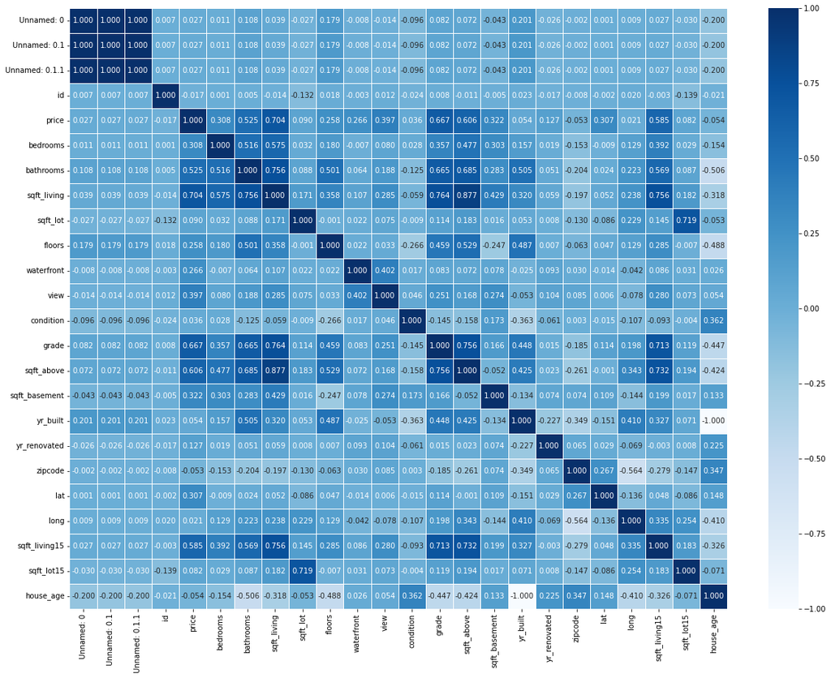

```python
import matplotlib.pyplot as plt
import seaborn
import numpy as np

corr_matrix = data.corr()
plt.figure(figsize=(20, 15))
seaborn.heatmap(corr_matrix, annot=True, fmt=".3f", linewidths=1, cmap="Blues")
```

```python
price_corr = corr_matrix["price"].drop("price")
price_corr
```

```
Unnamed: 0        0.027471
Unnamed: 0.1      0.027471
Unnamed: 0.1.1    0.027471
id               -0.016789
bedrooms          0.308184
bathrooms         0.525080
sqft_living       0.703949
sqft_lot          0.089632
floors            0.258488
waterfront        0.266429
view              0.397136
condition         0.036447
grade             0.667413
sqft_above        0.605612
sqft_basement     0.321731
yr_built          0.054039
yr_renovated      0.126648
zipcode          -0.053228
lat               0.306668
long              0.021412
sqft_living15     0.585180
sqft_lot15        0.082430
house_age        -0.053832
Name: price, dtype: float64
```

```python
dependent_to_price = price_corr[abs(price_corr) > 0.35]
dependent_to_price
```

```
bathrooms        0.525080
sqft_living      0.703949
view             0.397136
grade            0.667413
sqft_above       0.605612
sqft_living15    0.585180
Name: price, dtype: float64
```

Then I checked the number of unique values in each of those chosen features. Having too many unique values can be problematic in classification because it may cause our model to overfit(memorize each single data).

```python
data[dependent_to_price.index].nunique()
```

```
bathrooms         30
sqft_living      965
view               5
grade             12
sqft_above       946
sqft_living15    777
dtype: int64
```

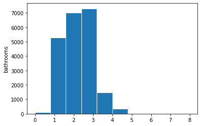

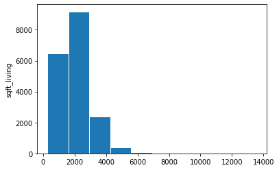

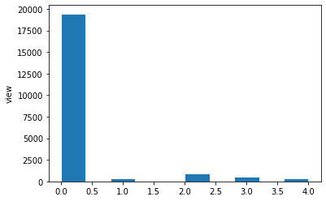

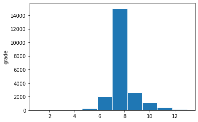

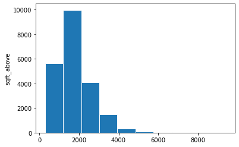

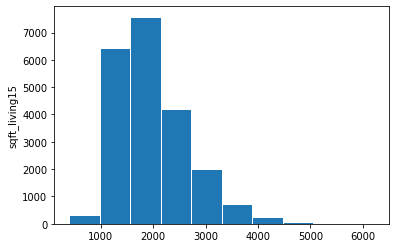

```python
for feature in dependent_to_price.index:
    plt.hist(data[feature], edgecolor='white')
    plt.ylabel(feature)
    plt.show()
```

In order to get a better understanding of the correlation of these features with price, I drew each feature with price in hexbin and scatter plots. In scatter plots for some continuous features we can see the linear relationship with price.(e.g `sqft_living`). hexbin plots shows the density of our data. For example we can infer that we have so many data with low view and low price or we have so many data with low number of bathrooms and low price. So we can infer that there can be a correlation from these hexbin plots too.

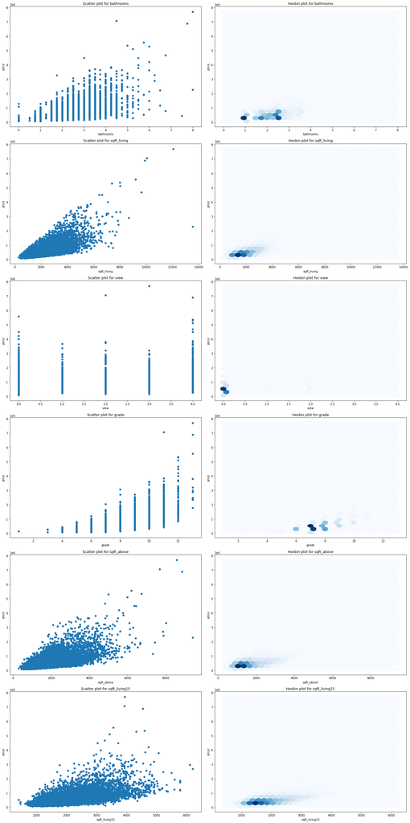

```python
fig, axs = plt.subplots(nrows=len(dependent_to_price.index), ncols=2, figsize=(20, 40))

for i, feature in enumerate(dependent_to_price.index):
    axs[i, 0].scatter(data[feature], data["price"])
    axs[i, 0].set_title(f'Scatter plot for {feature}')
    axs[i, 0].set_xlabel(feature)
    axs[i, 0].set_ylabel("price")

    axs[i, 1].hexbin(data[feature], data["price"], gridsize=30, cmap='Blues')
    axs[i, 1].set_title(f'Hexbin plot for {feature}')
    axs[i, 1].set_xlabel(feature)
    axs[i, 1].set_ylabel("price")

plt.tight_layout()
plt.show()
```

## Preprocessing

As I mentioned before We have to handle the missing data before making our ML models. we have different ways to handle missing values:

- `Deletion`: This involves removing rows or columns that contain missing values from the dataset. However, this method may result in loss of valuable information.
- `Imputation`: This involves replacing missing values with estimated values. Some imputation methods include mean imputation, mode imputation, median imputation, and regression imputation.
- `Interpolation`: This involves estimating missing values based on the available data. For example, linear interpolation can be used to estimate missing values between two known values.
- `Leave as-is`: Sometimes, it may be appropriate to leave missing values as they are if they do not significantly affect the analysis or interpretation of the data.

To make a decision, we have to see how much data is missing and they belong to which column:

```python
nan_values[nan_values["Missing"] != 0]
```

|  | Missing | Ratio |
| --- | --- | --- |
| sqft_living | 3082 | 0.142771 |
| floors | 3079 | 0.142632 |
| sqft_basement | 428 | 0.019827 |
| yr_built | 3077 | 0.142539 |

Because we don't have too many missing values for these columns I decided to go with median imputation. median imputation is better for discrete features and also it won't affect the variance like mean imputation does. It's also not affected by outliers.

```python
has_missing_cols = list(nan_values[nan_values["Missing"] != 0].index)
for col in has_missing_cols:
    data[col].fillna(data[col].median(), inplace=True)
data.isna().sum()
```

```
Unnamed: 0        0
Unnamed: 0.1      0
Unnamed: 0.1.1    0
id                0
date              0
price             0
bedrooms          0
bathrooms         0
sqft_living       0
sqft_lot          0
floors            0
waterfront        0
view              0
condition         0
grade             0
sqft_above        0
sqft_basement     0
yr_built          0
yr_renovated      0
zipcode           0
lat               0
long              0
sqft_living15     0
sqft_lot15        0
location          0
style             0
house_age         0
dtype: int64
```

We also need to normalize our data Because:

- It helps to improve the performance of some machine learning algorithms: Some machine learning algorithms, such as K-nearest neighbors (KNN), are sensitive to the scale of the input features. Normalizing the data can help to improve the performance of these algorithms by ensuring that all features are on a similar scale.
- it helps to avoid bias towards features with larger scales: When features have different scales, the machine learning algorithm may assign more importance to features with larger scales.
- it helps to reduce the influence of outliers: Outliers can have a significant impact on the mean and standard deviation of a feature, which can affect the performance of some machine learning algorithms.

I used sklearn's `StandardScaler` which use Standard Score method to normalize data. It makes data's distribution normal.(It makes sense because the histograms that we previously plotted were like normal distribution)

```python
from sklearn.preprocessing import StandardScaler

std_scaler = StandardScaler()
numeric_cols = data.select_dtypes(include="number")
data[numeric_cols.columns] = std_scaler.fit_transform(numeric_cols)
data["price"] = numeric_cols["price"]
data
```

|  | Unnamed: 0 | Unnamed: 0.1 | Unnamed: 0.1.1 | id | date | price | bedrooms | bathrooms | sqft_living | sqft_lot | ... | yr_built | yr_renovated | zipcode | lat | long | sqft_living15 | sqft_lot15 | location | style | house_age |
| --- | --- | --- | --- | --- | --- | --- | --- | --- | --- | --- | --- | --- | --- | --- | --- | --- | --- | --- | --- | --- | --- |
| 0 | -1.732283 | -1.732283 | -1.732283 | 0.885949 | 20141013T000000 | 221900.0 | -0.398810 | -1.447783 | -1.029481 | -0.228380 | ... | -0.604245 | -0.210140 | 1.870608 | -0.352605 | -0.306349 | -0.943583 | -0.260796 | Suburban | Contemporary | 0.544818 |
| 1 | -1.732123 | -1.732123 | -1.732123 | 0.637310 | 20141209T000000 | 538000.0 | -0.398810 | 0.175360 | 0.602403 | -0.189964 | ... | 0.129173 | 4.746389 | 0.879856 | 1.161331 | -0.746564 | -0.432934 | -0.187988 | Suburban | Ranch | 0.680986 |
| 2 | -1.731962 | -1.731962 | -1.731962 | 0.365239 | 20150225T000000 | 180000.0 | -1.474008 | -1.447783 | -1.510828 | -0.123413 | ... | -1.411005 | -0.210140 | -0.933409 | 1.283283 | -0.135943 | 1.069834 | -0.172504 | Rural | Victorian | 1.293745 |
| 3 | -1.731802 | -1.731802 | -1.731802 | -0.727876 | 20141209T000000 | 604000.0 | 0.676388 | 1.149246 | -0.113747 | -0.244064 | ... | -0.237536 | -0.210140 | 1.085483 | -0.283330 | -1.271983 | -0.914403 | -0.284589 | Urban | Colonial | 0.204396 |
| 4 | -1.731642 | -1.731642 | -1.731642 | -0.913104 | 20150218T000000 | 510000.0 | -0.398810 | -0.149269 | -0.442472 | -0.169743 | ... | 0.569224 | -0.210140 | -0.073510 | 0.409414 | 1.198905 | -0.272444 | -0.192966 | Suburban | Cape Cod | -0.544531 |
| ... | ... | ... | ... | ... | ... | ... | ... | ... | ... | ... | ... | ... | ... | ... | ... | ... | ... | ... | ... | ... | ... |
| 21582 | 1.731063 | 1.731063 | 1.731063 | -1.501119 | 20140521T000000 | 360000.0 | -0.398810 | 0.499988 | -0.618575 | -0.337424 | ... | 1.375983 | -0.210140 | 0.468600 | 1.004742 | -0.938271 | -0.666373 | -0.412378 | Suburban | Victorian | -1.293458 |
| 21583 | 1.731223 | 1.731223 | 1.731223 | 0.701959 | 20150223T000000 | 400000.0 | 0.676388 | 0.499988 | 0.297159 | -0.224446 | ... | 1.559338 | -0.210140 | 1.272418 | -0.356213 | -1.051875 | -0.228674 | -0.204058 | Suburban | Cape Cod | -1.463668 |
| 21584 | 1.731383 | 1.731383 | 1.731383 | -1.062976 | 20140623T000000 | 402101.0 | -1.474008 | -1.772412 | -1.217323 | -0.332140 | ... | 0.129173 | -0.210140 | 1.235031 | 0.247774 | -0.604559 | -1.410462 | -0.394149 | Suburban | Ranch | -1.293458 |
| 21585 | 1.731544 | 1.731544 | 1.731544 | -1.491277 | 20150116T000000 | 400000.0 | -0.398810 | 0.499988 | -0.536393 | -0.307093 | ... | 1.192629 | -0.210140 | -0.952102 | -0.184470 | 1.028499 | -0.841453 | -0.420505 | Rural | Contemporary | -1.123247 |
| 21586 | 1.731704 | 1.731704 | 1.731704 | -1.062976 | 20141015T000000 | 325000.0 | -1.474008 | -1.772412 | -1.217323 | -0.338751 | ... | 1.339313 | -0.210140 | 1.235031 | 0.245609 | -0.604559 | -1.410462 | -0.417942 | Rural | Ranch | -1.259415 |

21587 rows × 27 columns

We have to change our categorical columns because for ML models it's easier to work with numbers. There several approaches to encode categorical features, such as:

- `Label Encoding`: Simply Assign a number to each category.
- `One-Hot Encoding`: We add one binary feature per each unique category.
- `Binary Encoding` : Is something between Label Encoding and One-hot Encoding. We turn those numbers to binary and then each bit is a new feature.
- `Frequency Encoding`: We replace each category with its frequency in the column.
- `Target Encoding`: We replace each category with the mean of our target(here price) when the value of the feature is that specific category.

I used Label Encoding because I didn't want to add more features and wanted to keep it simple.

```python
import category_encoders as cat_enc

cat_cols = data.select_dtypes(include=['category', 'object'])
label_enc = cat_enc.OrdinalEncoder(cols = cat_cols.columns)
data[cat_cols.columns] = label_enc.fit_transform(cat_cols)
data
```

|  | Unnamed: 0 | Unnamed: 0.1 | Unnamed: 0.1.1 | id | date | price | bedrooms | bathrooms | sqft_living | sqft_lot | ... | yr_built | yr_renovated | zipcode | lat | long | sqft_living15 | sqft_lot15 | location | style | house_age |
| --- | --- | --- | --- | --- | --- | --- | --- | --- | --- | --- | --- | --- | --- | --- | --- | --- | --- | --- | --- | --- | --- |
| 0 | -1.732283 | -1.732283 | -1.732283 | 0.885949 | 1 | 221900.0 | -0.398810 | -1.447783 | -1.029481 | -0.228380 | ... | -0.604245 | -0.210140 | 1.870608 | -0.352605 | -0.306349 | -0.943583 | -0.260796 | 1 | 1 | 0.544818 |
| 1 | -1.732123 | -1.732123 | -1.732123 | 0.637310 | 2 | 538000.0 | -0.398810 | 0.175360 | 0.602403 | -0.189964 | ... | 0.129173 | 4.746389 | 0.879856 | 1.161331 | -0.746564 | -0.432934 | -0.187988 | 1 | 2 | 0.680986 |
| 2 | -1.731962 | -1.731962 | -1.731962 | 0.365239 | 3 | 180000.0 | -1.474008 | -1.447783 | -1.510828 | -0.123413 | ... | -1.411005 | -0.210140 | -0.933409 | 1.283283 | -0.135943 | 1.069834 | -0.172504 | 2 | 3 | 1.293745 |
| 3 | -1.731802 | -1.731802 | -1.731802 | -0.727876 | 2 | 604000.0 | 0.676388 | 1.149246 | -0.113747 | -0.244064 | ... | -0.237536 | -0.210140 | 1.085483 | -0.283330 | -1.271983 | -0.914403 | -0.284589 | 3 | 4 | 0.204396 |
| 4 | -1.731642 | -1.731642 | -1.731642 | -0.913104 | 4 | 510000.0 | -0.398810 | -0.149269 | -0.442472 | -0.169743 | ... | 0.569224 | -0.210140 | -0.073510 | 0.409414 | 1.198905 | -0.272444 | -0.192966 | 1 | 5 | -0.544531 |
| ... | ... | ... | ... | ... | ... | ... | ... | ... | ... | ... | ... | ... | ... | ... | ... | ... | ... | ... | ... | ... | ... |
| 21582 | 1.731063 | 1.731063 | 1.731063 | -1.501119 | 232 | 360000.0 | -0.398810 | 0.499988 | -0.618575 | -0.337424 | ... | 1.375983 | -0.210140 | 0.468600 | 1.004742 | -0.938271 | -0.666373 | -0.412378 | 1 | 3 | -1.293458 |
| 21583 | 1.731223 | 1.731223 | 1.731223 | 0.701959 | 53 | 400000.0 | 0.676388 | 0.499988 | 0.297159 | -0.224446 | ... | 1.559338 | -0.210140 | 1.272418 | -0.356213 | -1.051875 | -0.228674 | -0.204058 | 1 | 5 | -1.463668 |
| 21584 | 1.731383 | 1.731383 | 1.731383 | -1.062976 | 97 | 402101.0 | -1.474008 | -1.772412 | -1.217323 | -0.332140 | ... | 0.129173 | -0.210140 | 1.235031 | 0.247774 | -0.604559 | -1.410462 | -0.394149 | 1 | 2 | -1.293458 |
| 21585 | 1.731544 | 1.731544 | 1.731544 | -1.491277 | 130 | 400000.0 | -0.398810 | 0.499988 | -0.536393 | -0.307093 | ... | 1.192629 | -0.210140 | -0.952102 | -0.184470 | 1.028499 | -0.841453 | -0.420505 | 2 | 1 | -1.123247 |
| 21586 | 1.731704 | 1.731704 | 1.731704 | -1.062976 | 226 | 325000.0 | -1.474008 | -1.772412 | -1.217323 | -0.338751 | ... | 1.339313 | -0.210140 | 1.235031 | 0.245609 | -0.604559 | -1.410462 | -0.417942 | 2 | 2 | -1.259415 |

21587 rows × 27 columns

```python
data.columns
```

```
Index(['Unnamed: 0', 'Unnamed: 0.1', 'Unnamed: 0.1.1', 'id', 'date', 'price',
       'bedrooms', 'bathrooms', 'sqft_living', 'sqft_lot', 'floors',
       'waterfront', 'view', 'condition', 'grade', 'sqft_above',
       'sqft_basement', 'yr_built', 'yr_renovated', 'zipcode', 'lat', 'long',
       'sqft_living15', 'sqft_lot15', 'location', 'style', 'house_age'],
      dtype='object')
```

`Unnamed` columns have to be dropped because they don't make sense. `date` and `id` doesn't affect price so I dropeed them too. `long` can be important because it's important to know where the house is but we already have `location`, so I dropped it too.

```python
data = data.drop(['Unnamed: 0', 'Unnamed: 0.1', 'Unnamed: 0.1.1', 'id', 'date', 'long'], axis = "columns")
```

For splitting data, a common rule of thumb is to use a ratio of 70:30 or 80:20 for the train-test split, meaning that 70-80% of the data is used for training the model and the remaining 20-30% is used for testing the model. There are some ways to split data to train and test:

- `Random split`: The data is randomly split into train and test sets.
- `Stratified split`: The data is split into train and test sets while maintaining the same proportion of classes in each set.
- `K-fold cross-validation`: The data is split into K equally sized folds, and the model is trained and evaluated K times, with each fold used once as the test set and the remaining folds used as the training set.

```python
from sklearn.model_selection import train_test_split

features = data.drop("price", axis = "columns")
X_train, X_test, y_train, y_test = train_test_split(features, data["price"], test_size=0.2, random_state=42)
```

```python
display(X_train)
display(y_train)
```

|  | bedrooms | bathrooms | sqft_living | sqft_lot | floors | waterfront | view | condition | grade | sqft_above | sqft_basement | yr_built | yr_renovated | zipcode | lat | sqft_living15 | sqft_lot15 | location | style | house_age |
| --- | --- | --- | --- | --- | --- | --- | --- | --- | --- | --- | --- | --- | --- | --- | --- | --- | --- | --- | --- | --- |
| 8977 | -0.398810 | 0.499988 | 0.179757 | -0.156664 | 0.012216 | -0.087226 | -0.305889 | -0.629407 | 0.292055 | 0.508957 | -0.650631 | 0.605895 | -0.210140 | -0.914716 | 0.082526 | 0.515415 | -0.204351 | 3 | 4 | -0.578573 |
| 7217 | -0.398810 | -1.447783 | -1.264284 | -0.248890 | 0.012216 | -0.087226 | -0.305889 | -0.629407 | -0.558768 | -0.976184 | -0.650631 | -1.667701 | -0.210140 | 0.749001 | 0.045002 | 0.063126 | -0.204058 | 1 | 2 | 1.532040 |
| 19460 | 0.676388 | 1.473874 | 2.046445 | 0.113015 | 1.014942 | -0.087226 | -0.305889 | -0.629407 | 1.993701 | 2.428774 | -0.650631 | -0.090853 | 4.791199 | -1.344665 | 0.060156 | 2.849811 | 0.226969 | 3 | 4 | 0.068228 |
| 5363 | 0.676388 | 0.499988 | 0.226718 | -0.090861 | 1.014942 | -0.087226 | -0.305889 | -0.629407 | 0.292055 | 0.557255 | -0.650631 | 0.715907 | -0.210140 | -0.821248 | 1.089891 | 0.179845 | -0.102881 | 1 | 2 | -0.680699 |
| 13225 | -1.474008 | -1.447783 | -0.959040 | -0.210282 | 0.012216 | -0.087226 | 0.999098 | 0.907584 | -0.558768 | -0.879590 | -0.241679 | -1.227650 | -0.210140 | 0.898549 | -0.077672 | -1.089483 | -0.233342 | 1 | 3 | 1.123534 |
| ... | ... | ... | ... | ... | ... | ... | ... | ... | ... | ... | ... | ... | ... | ... | ... | ... | ... | ... | ... | ... |
| 11964 | 0.676388 | 3.097017 | 2.545402 | 6.488546 | 1.014942 | -0.087226 | -0.305889 | 0.907584 | 2.844524 | 2.941933 | -0.650631 | 0.495882 | -0.210140 | -0.073510 | 0.373334 | 1.288684 | 0.065943 | 2 | 4 | -0.476446 |
| 21575 | -0.398810 | 0.499988 | -0.741846 | -0.336266 | 3.020394 | -0.087226 | -0.305889 | -0.629407 | 0.292055 | -0.438877 | -0.650631 | 1.339313 | -0.210140 | 0.879856 | 0.983093 | -1.023828 | -0.421749 | 2 | 3 | -1.259415 |
| 5390 | -0.398810 | -1.447783 | -1.229064 | -0.169067 | -0.990509 | -0.087226 | -0.305889 | -0.629407 | -0.558768 | -0.939961 | -0.650631 | -0.604245 | -0.210140 | 1.440659 | 1.262356 | -1.279152 | -0.170820 | 1 | 4 | 0.544818 |
| 860 | -0.398810 | -0.473897 | -0.477693 | -0.119793 | 0.012216 | -0.087226 | -0.305889 | -0.629407 | 0.292055 | -0.674326 | 0.303589 | 0.165844 | -0.210140 | -0.839942 | 0.983093 | -0.082774 | -0.139706 | 3 | 2 | -0.170067 |
| 15795 | -1.474008 | -1.447783 | -1.546048 | -0.151090 | -0.990509 | -0.087226 | -0.305889 | -0.629407 | -1.409591 | -1.265968 | -0.650631 | -1.044296 | -0.210140 | 1.646287 | -0.582798 | -1.658492 | -0.146404 | 1 | 5 | 0.953323 |

17269 rows × 20 columns

```
8977      590000.0
7217      425000.0
19460    2400000.0
5363      572650.0
13225     559000.0
           ...
11964    1010000.0
21575     467000.0
5390      200000.0
860       539900.0
15795     230500.0
Name: price, Length: 17269, dtype: float64
```

```python
X_test
```

|  | bedrooms | bathrooms | sqft_living | sqft_lot | floors | waterfront | view | condition | grade | sqft_above | sqft_basement | yr_built | yr_renovated | zipcode | lat | sqft_living15 | sqft_lot15 | location | style | house_age |
| --- | --- | --- | --- | --- | --- | --- | --- | --- | --- | --- | --- | --- | --- | --- | --- | --- | --- | --- | --- | --- |
| 20113 | -0.398810 | 0.499988 | 0.121056 | -0.318579 | 1.014942 | -0.087226 | -0.305889 | -0.629407 | 1.142878 | 0.219174 | -0.218960 | 1.559338 | -0.21014 | 0.749001 | 0.029848 | -0.257854 | -0.370502 | 1 | 4 | -1.463668 |
| 7826 | 0.676388 | 0.499988 | -0.125487 | -0.286896 | 1.014942 | -0.087226 | -0.305889 | -0.629407 | -0.558768 | 0.195025 | -0.650631 | 1.119287 | -0.21014 | 1.870608 | -0.423322 | -0.009824 | -0.349564 | 3 | 4 | -1.055163 |
| 3820 | 1.751586 | 1.473874 | 1.835122 | -0.231999 | 1.014942 | -0.087226 | 2.304084 | -0.629407 | 1.142878 | 2.211436 | -0.650631 | 1.155958 | -0.21014 | -0.914716 | -0.114474 | 1.857693 | -0.266287 | 3 | 5 | -1.089205 |
| 9595 | 2.826784 | 2.123131 | 2.058185 | -0.216314 | 1.014942 | -0.087226 | -0.305889 | 0.907584 | 0.292055 | 2.440849 | -0.650631 | 0.129173 | -0.21014 | 0.468600 | 0.966496 | -0.228674 | -0.280014 | 3 | 2 | -0.204109 |
| 20950 | -0.398810 | 0.499988 | -0.559874 | -0.332840 | 1.014942 | -0.087226 | 2.304084 | -0.629407 | 0.292055 | -0.855441 | 0.485345 | 1.559338 | -0.21014 | 0.543373 | 0.784651 | -0.666373 | -0.417942 | 1 | 1 | -1.463668 |
| ... | ... | ... | ... | ... | ... | ... | ... | ... | ... | ... | ... | ... | ... | ... | ... | ... | ... | ... | ... | ... |
| 4989 | -0.398810 | -0.473897 | -0.407251 | 0.017604 | -0.990509 | -0.087226 | -0.305889 | 0.907584 | 0.292055 | -0.094759 | -0.650631 | -0.274207 | -0.21014 | -0.353912 | -0.645578 | 0.004766 | 0.277631 | 3 | 4 | 0.238438 |
| 9693 | -0.398810 | -0.473897 | -0.372031 | -0.179347 | 0.012216 | -0.087226 | -0.305889 | -0.629407 | 0.292055 | -0.553583 | 0.280869 | 0.239186 | -0.21014 | -0.372606 | -0.829588 | 0.033946 | -0.144757 | 2 | 3 | -0.238151 |
| 17592 | -0.398810 | -1.447783 | -0.160708 | -0.195804 | -0.990509 | -0.087226 | -0.305889 | 0.907584 | -0.558768 | -0.577732 | -0.650631 | -0.494232 | -0.21014 | -1.307278 | 0.301895 | -1.031123 | -0.200397 | 1 | 1 | 0.442691 |
| 16951 | -0.398810 | 0.499988 | -0.019826 | -0.253065 | 1.014942 | -0.087226 | -0.305889 | -0.629407 | 0.292055 | 0.303694 | -0.650631 | 0.752578 | -0.21014 | -0.484766 | 0.551571 | 0.354925 | -0.302892 | 3 | 5 | -0.714741 |
| 18258 | -0.398810 | 0.499988 | 0.367600 | -0.145082 | 1.014942 | -0.087226 | -0.305889 | -0.629407 | 1.142878 | 0.702146 | -0.650631 | 0.679236 | -0.21014 | -1.026876 | -1.828295 | 0.792624 | -0.105846 | 2 | 4 | -0.646657 |

4318 rows × 20 columns

## Linear Regression

Main form of simple linear regression function: $$f(x) = \alpha x + \beta$$

- step 1: Compute RSS of the training data

$$ RSS = \Sigma (y_i - (\hat{\beta} + \hat{\alpha} * x_i) )^2 $$

- step 2: Compute the derivatives of the RSS function in term of $\underline{\alpha}$ and $\underline{\beta}$, and set them equal to 0 to find the desired parameters

$$ \frac{\partial RSS}{\partial \beta} = \Sigma (-f(x_i) + \hat{\beta} + \hat{\alpha} * x_i) = 0$$$$ \to \hat{\beta} = \hat{y} - \hat{\alpha} \hat{x} \to (1)$$$$ \frac{\partial RSS}{\partial \alpha} = \Sigma (-2 x_i y_i + 2 \hat{\beta} x_i + 2\hat{\alpha} x_i ^ 2) = 0 \to (2)$$$$ (1) , (2) \to \hat{\alpha} = \frac{\Sigma{(x_i - \hat{x})(y_i - \hat{y})}}{\Sigma{(x_i - \hat{x})^2}} $$

$$ \hat{\beta} = \hat{y} - \hat{\alpha} \hat{x}$$

Based on the formula above, I made a Simple Linear Regression function:

```python
import numpy as np
import math
def simple_linear_regression(input_feature, output):
    Sxy = (input_feature * output).sum() - input_feature.sum() * output.sum() / len(output)
    Sxx = (input_feature ** 2).sum() - (input_feature.sum())**2 / len(output)
    slope = Sxy / Sxx
    intercept = output.mean() - slope * input_feature.mean()
    return (intercept, slope)
```

```python
def get_regression_predictions(input_feature, intercept, slope):
    return input_feature * slope + intercept
```

RMSE is the square root of the mean of the squared differences between the residuals and the residuals is just a fancy word for the difference between the predicted output and the true output.

```python
def get_root_mean_square_error(predicted_values , output):
    residuals = predicted_values - output
    residuals_sum_sqr = (residuals ** 2).sum()
    mean_residual_sqr = residuals_sum_sqr/len(predicted_values)
    return math.sqrt(mean_residual_sqr)
```

The RMSE has no bound and it is not easy to find out the percentage of fitting the model into data with it. instead, we use R2 score. The R2 score is calculated by comparing the sum of the squared differences between the actual and predicted values of the dependent variable to the total sum of squared differences between the actual and mean values of the dependent variable. Matematically, the R2 score formula is shown as follows:

$$R^2 = 1 - \frac{SSres}{SStot} = 1 - \frac{\sum_{i=1}^{n} (y_{i,true} - y_{i,pred})^2}{\sum_{i=1}^{n} (y_{i,true} - \bar{y}_{true})^2} $$

```python
def get_r2_score(predicted_values, output):
    residuals = predicted_values - output
    SSres = (residuals ** 2).sum()
    SStot = ((output - output.mean())**2).sum()
    return 1 - SSres / SStot
```

We have another famous metric too:

- `Mean Squared Error(MSE)`: The MSE measures the average of the squared differences between the predicted values and the actual values. The lower the MSE, the better the model fits the data. The formula for calculating MSE is: $$ MSE = \frac{1}{n}\sum{(y_{i,true} - y_{i,pred})^2} $$

For calculating the fitness of our model I wrote a new function(`test_simple_linear_regression`) which gets a feature and make the model with that feature and the calculates R2 score and RMSE for it. It also plots the data with the regression line.

```python
def test_simple_linear_regression(feature, ax):
    intercept, slope = simple_linear_regression(X_train[feature], y_train)
    predicted_values = get_regression_predictions(X_test[feature], intercept, slope)
    rmse = get_root_mean_square_error(predicted_values, y_test)
    r2_score = get_r2_score(predicted_values, y_test)
    print(f"{feature}:\n RMSE: {rmse:0.3f}, R^2: {r2_score}")
    ax.scatter(X_train[feature], y_train)
    x_line = np.linspace(min(data[feature]), max(data[feature]), 100)
    y_line = intercept * x_line + slope
    ax.plot(x_line, y_line, color='red', label = f"y = {slope:0.2f} * x + {intercept:0.2f}")

    ax.set_ylabel("price")
    #ax.set_xlabel(feature)
    ax.set_title(feature)
    ax.legend()
```

I chose the features that had significant correlation with price + zipcode whcih we were asked to test!

```
zipcode:
 RMSE: 388660.924, R^2: 0.001636224002450004
bathrooms:
 RMSE: 324005.277, R^2: 0.3061729577563833
sqft_living:
 RMSE: 289000.470, R^2: 0.4479935461636505
view:
 RMSE: 351597.218, R^2: 0.1829701621501576
grade:
 RMSE: 287215.835, R^2: 0.45478999432321254
sqft_above:
 RMSE: 304827.603, R^2: 0.3858766112091975
sqft_living15:
 RMSE: 316979.273, R^2: 0.3359377578417848
```

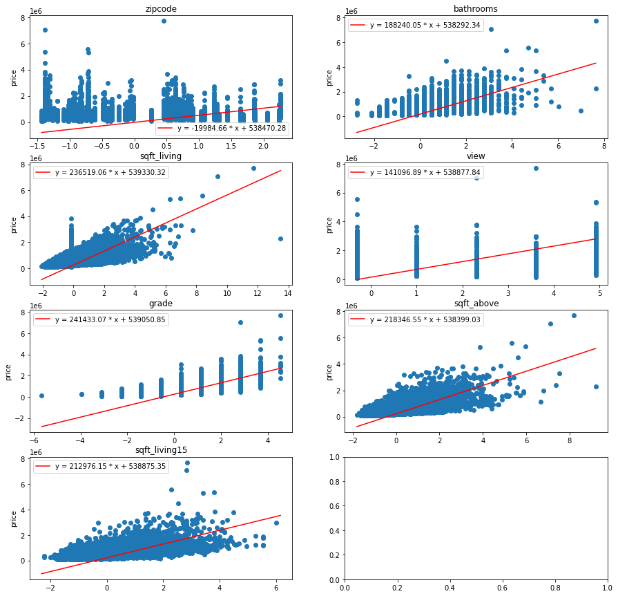

```python
designated_feature_list = ['zipcode'] + list(dependent_to_price.index)

figure, axs = plt.subplots(nrows=4, ncols=2, figsize=(15,15))
axs = axs.flatten()
for ax, feature in zip(axs, designated_feature_list):
    test_simple_linear_regression(feature, ax)
```

Except zipcode, other features have R2 scores so higher than 0 which means they're so much better than simply guessing the mean of data but they're not good enough(all of them are less than 0.5). It means we can't guess the price with simply one data.

## Classification

In this phase we want to make classification models to predict if the price of the house is higher than the median or lower than it. So first we have to add a new column to data that says if the price is low or high. Then, I splitted the data into train and test. I also only used features that had more than 0.1 correlation with price.

```python
price_corr = data.corr()["price"].drop("price")
dependent_to_price = price_corr[abs(price_corr) > 0.1]
dependent_to_price
```

```
bedrooms         0.308184
bathrooms        0.525080
sqft_living      0.654246
floors           0.240011
waterfront       0.266429
view             0.397136
grade            0.667413
sqft_above       0.605612
sqft_basement    0.317652
yr_renovated     0.126648
lat              0.306668
sqft_living15    0.585180
Name: price, dtype: float64
```

```python
#data['price_level'] = data['price'].apply(lambda x: 'LOW' if x < data["price"].median() else 'HIGH')
data["price_level"] = (data["price"] > data["price"].median()).astype(int)
features = data.drop(["price", "price_level"], axis="columns")
dependent_features = data[dependent_to_price.index]#.drop(["price_level"], axis="columns")

X_train, X_test, y_train, y_test = train_test_split(dependent_features, data["price_level"], test_size=0.2)
```

```python
display(X_train)
display(y_train)
```

|  | bedrooms | bathrooms | sqft_living | floors | waterfront | view | grade | sqft_above | sqft_basement | yr_renovated | lat | sqft_living15 |
| --- | --- | --- | --- | --- | --- | --- | --- | --- | --- | --- | --- | --- |
| 19311 | -1.474008 | -1.447783 | -1.146882 | -0.990509 | -0.087226 | -0.305889 | -0.558768 | -0.855441 | -0.650631 | -0.21014 | 0.939075 | -0.666373 |
| 7542 | -0.398810 | -0.149269 | -1.017741 | -0.990509 | -0.087226 | -0.305889 | -0.558768 | -0.722623 | -0.650631 | -0.21014 | -0.392293 | -0.097364 |
| 19278 | 4.977179 | 1.149246 | 2.093406 | -0.990509 | -0.087226 | -0.305889 | -0.558768 | 0.895336 | 2.325625 | -0.21014 | 1.089891 | -0.885223 |
| 12755 | -0.398810 | 0.824617 | -0.160708 | 0.012216 | -0.087226 | -0.305889 | 0.292055 | -0.674326 | 0.985174 | -0.21014 | 0.505388 | 0.004766 |
| 21183 | 0.676388 | 0.499988 | -0.160708 | 1.014942 | -0.087226 | -0.305889 | -0.558768 | 0.315768 | -0.650631 | -0.21014 | -0.498370 | 0.719674 |
| ... | ... | ... | ... | ... | ... | ... | ... | ... | ... | ... | ... | ... |
| 12605 | -0.398810 | -0.798526 | -0.735976 | -0.990509 | -0.087226 | -0.305889 | -0.558768 | -0.432840 | -0.650631 | -0.21014 | 0.197261 | -0.783093 |
| 13961 | -0.398810 | 0.499988 | 0.391080 | -0.990509 | -0.087226 | 2.304084 | 0.292055 | -0.420765 | 1.507723 | -0.21014 | 0.081804 | 0.033946 |
| 18331 | -0.398810 | 0.499988 | -0.651447 | 3.020394 | -0.087226 | -0.305889 | -0.558768 | -0.345905 | -0.650631 | -0.21014 | 0.974434 | -0.889600 |
| 439 | -0.398810 | 0.175360 | 0.015395 | 1.014942 | -0.087226 | -0.305889 | -0.558768 | 0.339917 | -0.650631 | -0.21014 | -1.575732 | -0.141134 |
| 5062 | 0.676388 | 0.499988 | 0.541355 | 0.012216 | -0.087226 | -0.305889 | 0.292055 | 0.880846 | -0.650631 | -0.21014 | 0.211693 | 0.427875 |

17269 rows × 12 columns

```
19311    0
7542     0
19278    1
12755    1
21183    0
        ..
12605    1
13961    1
18331    0
439      0
5062     1
Name: price_level, Length: 17269, dtype: int32
```

```python
display(X_test)
```

|  | bedrooms | bathrooms | sqft_living | floors | waterfront | view | grade | sqft_above | sqft_basement | yr_renovated | lat | sqft_living15 |
| --- | --- | --- | --- | --- | --- | --- | --- | --- | --- | --- | --- | --- |
| 16194 | -0.398810 | 0.824617 | 0.121056 | -0.990509 | -0.087226 | -0.305889 | -0.558768 | -0.493211 | 1.121491 | -0.21014 | -0.179418 | -1.001943 |
| 20632 | -0.398810 | 0.499988 | 1.365515 | 1.014942 | -0.087226 | -0.305889 | 1.142878 | 1.728464 | -0.650631 | -0.21014 | -0.566922 | 1.959823 |
| 21152 | 0.676388 | 0.499988 | 1.142451 | 1.014942 | -0.087226 | -0.305889 | 1.142878 | 1.499052 | -0.650631 | -0.21014 | 0.962167 | 1.522123 |
| 17847 | 0.676388 | 0.175360 | 0.402820 | 0.012216 | -0.087226 | -0.305889 | 0.292055 | 0.738369 | -0.650631 | -0.21014 | -0.749489 | 0.267385 |
| 13649 | -0.398810 | 0.499988 | 0.261938 | -0.990509 | -0.087226 | -0.305889 | 1.142878 | -1.000333 | 2.348345 | -0.21014 | 1.336682 | 1.624253 |
| ... | ... | ... | ... | ... | ... | ... | ... | ... | ... | ... | ... | ... |
| 3689 | -0.398810 | 0.175360 | -0.102007 | -0.990509 | -0.087226 | -0.305889 | 0.292055 | -0.384542 | 0.485345 | -0.21014 | 0.795475 | -0.009824 |
| 17627 | -0.398810 | 0.175360 | -0.724236 | -0.990509 | -0.087226 | -0.305889 | 0.292055 | -0.795069 | 0.053674 | -0.21014 | -1.746753 | -0.695553 |
| 19901 | -1.474008 | -0.473897 | -0.923819 | 0.012216 | -0.087226 | -0.305889 | 0.292055 | -0.626029 | -0.650631 | -0.21014 | 0.034178 | -1.235382 |
| 7095 | -0.398810 | 0.499988 | 0.109316 | -0.990509 | -0.087226 | -0.305889 | 0.292055 | -0.287948 | 0.712540 | -0.21014 | -0.737944 | -0.053594 |
| 15565 | 0.676388 | 0.175360 | 0.015395 | -0.990509 | -0.087226 | -0.305889 | 0.292055 | -0.481137 | 0.894296 | -0.21014 | 0.988145 | 0.179845 |

4318 rows × 12 columns

I made an abstract class `ClassifierModel` which every classifier model that I later make will be a subclass of this class. This class does the usual things tha each classifier should do like fitting, predicting, calculating accuracy, tuning hyperparameters and drawing confusion matrix. The only things that each subclass should do are specifying their classifier and their hyperparameters.

```python
from abc import ABC, abstractmethod
from sklearn import metrics
from sklearn.model_selection import GridSearchCV

class ClassifierModel(ABC):
    def __init__(self, X_train, y_train, params):
        self.classifier = self.create_classifier(params)
        self.search_params = self.set_search_params()
        self.classifier.fit(X_train, y_train)
        self.train_accuracy = self.calc_accuracy(X_train, y_train)

    @abstractmethod
    def create_classifier(self, params):
        pass

    @abstractmethod
    def set_search_params(self):
        pass

    def predict(self, data):
        return self.classifier.predict(data)

    def get_train_accuracy(self):
        return self.train_accuracy

    def calc_accuracy(self, X_test, y_test):
        preds = self.predict(X_test)
        accuracy = metrics.accuracy_score(y_test, preds)
        return accuracy

    def grid_search(self, X_train, y_train, X_test, y_test):
        grid = GridSearchCV(self.classifier, self.search_params, scoring='accuracy', n_jobs = 2)
        grid.fit(X_train, y_train)
        test_score = grid.score(X_test, y_test)
        return grid, test_score

    def draw_confusion_matrix(self, X_test, y_test):
        preds = self.classifier.predict(X_test)
        confusion_matrix = metrics.confusion_matrix(y_test, preds)
        fig, ax = plt.subplots(figsize=(8, 6))
        matrix_plot = metrics.ConfusionMatrixDisplay(confusion_matrix)
        matrix_plot.plot(cmap='Blues', ax = ax)
        plt.title('Confusion Matrix')
        plt.show()
```

In a confusion matrix, we have the following structure:

|  |  | **Predicted** | **Results** |
| --- | --- | --- | --- |
|  | *Value* | *0* | *1* |
| **Actual** | *0* | TN | FP |
| **Results** | *1* | FN | TP |

I wrote a function (`run_model`) that gets a classifier model and shows its accuracy and grid-search result and in the end plot its confusion matrix.

```python
def run_model(Model, X_train, y_train, X_test, y_test, params):
    model = Model(X_train, y_train, params)
    print(f"model's train accuracy: {model.get_train_accuracy(): 0.3f}")
    print(f"model's test accuracy: {model.calc_accuracy(X_test, y_test): 0.3f}")
    grid, test_score = model.grid_search(X_train, y_train, X_test, y_test)
    print(f"Best hyperparameters: {grid.best_params_}")
    print(f"Best model's train accuracy score: {grid.best_score_:0.3f}")
    print(f"Best model's test score: {test_score:0.3f}")
    model.draw_confusion_matrix(X_test, y_test)
```

Now we define 3 classifiers:

### Decision tree

A decision tree is a supervised learning algorithm that predicts a target variable by recursively partitioning the feature space into subsets based on the values of the input features. It creates a tree structure where each internal node represents a test on a feature, each branch represents an outcome of the test, and each leaf node represents a class label or a regression value. The hyperparameters that I change are:

- `criterion` refers to the function used to measure the quality of a split.
- `Max_depth` is the maximum depth of the decision tree.
- `Min_samples_split` is the minimum number of samples required to split an internal node.
- `min_samples_leaf` is the minimum number of samples required to be at a leaf node.

```python
from sklearn.tree import DecisionTreeClassifier

class DecisionTreeModel(ClassifierModel):
    def create_classifier(self, params):
        return DecisionTreeClassifier(criterion=params["criterion"], max_depth=params["max_depth"],
                                      min_samples_split=params["min_samples_split"], min_samples_leaf=params["min_samples_leaf"])

    def set_search_params(self):
        return {
            'criterion': ["gini", "entropy"],
            'max_depth': range(4, 12),
            'min_samples_split': range(2, 12),
            'min_samples_leaf': range(1, 6),
        }
```

```
model's train accuracy:  0.890
model's test accuracy:  0.870
Best hyperparameters: {'criterion': 'gini', 'max_depth': 9, 'min_samples_leaf': 1, 'min_samples_split': 2}
Best model's train accuracy score: 0.875
Best model's test score: 0.877
```

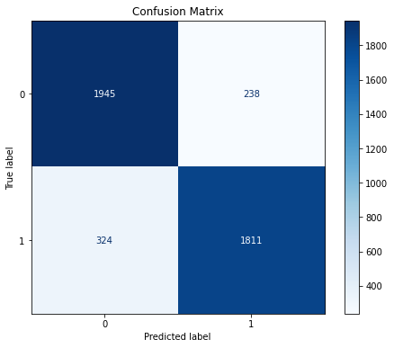

```python
params = {
        'criterion': "entropy",
        'max_depth': 8,
        'min_samples_split': 5,
        'min_samples_leaf': 8,
}
run_model(DecisionTreeModel, X_train, y_train, X_test, y_test, params)
```

From confusion matrix we can infer accuracy: $$Accuracy = \frac{TP + TN}{TP + TN + FP + FN} = 87.0 \%$$

`Overfitting` occurs when a machine learning model performs well on the training data but poorly on new, unseen data. This happens when the model learns the noise in the training data instead of capturing the underlying patterns.

`Underfitting` occurs when a model is too simple to capture the underlying patterns in the data, resulting in poor performance on both the training and test data. This happens when the model is not complex enough to learn the relationships between the input features and the target variable.

Here our model both performs well on test and train so we don't have overfitting nor underfitting.

### K-Nearest Neighbors

KNN (k-nearest neighbors) is a supervised learning algorithm that predicts a target variable based on the k-nearest neighbors in the feature space. It classifies or regresses based on the majority class or average of the neighboring data points. I simply changed `n_neighbors` for this model.

```python
from sklearn.neighbors import KNeighborsClassifier


class KNNModel(ClassifierModel):
    def create_classifier(self, params):
        return KNeighborsClassifier(n_neighbors=params["n_neighbors"])

    def set_search_params(self):
        return {
                'n_neighbors' : range(1, 90)
        }
```

```
model's train accuracy:  0.887
model's test accuracy:  0.874
Best hyperparameters: {'n_neighbors': 31}
Best model's train accuracy score: 0.870
Best model's test score: 0.868
```

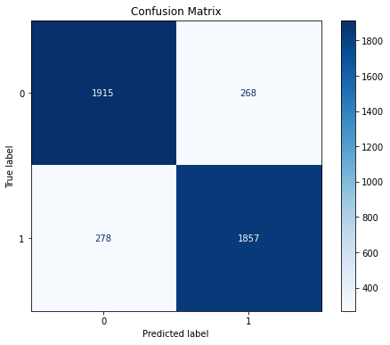

```python
params = {
        'n_neighbors' : 18
}
run_model(KNNModel, X_train, y_train, X_test, y_test, params)
```

From confusion matrix we can infer accuracy: $$Accuracy = \frac{TP + TN}{TP + TN + FP + FN} = 87.4 \%$$ Here our model both performs well on test and train so we don't have overfitting nor underfitting.

### Logistic Regression

Logistic regression is a supervised learning algorithm used for binary classification problems. It models the probability of the target variable belonging to a specific class as a function of the input features using a logistic function, and predicts the class with the highest probability. The hyperparameters that I changed are:

- `C`: Inverse of regularization strength.
- `solver`: Algorithm to use in the optimization problem.
- `penalty`: Specify the norm of the penalty.

```python
from sklearn.linear_model import LogisticRegression

class LogisticRegressionModel(ClassifierModel):
    def create_classifier(self, params):
        return LogisticRegression(max_iter = 500)

    def set_search_params(self):
        return {
            'C': [0.001, 0.01, 0.1, 1, 10, 100, 1000],
            'penalty': ['l2'],
            'solver': ['newton-cg', 'lbfgs', 'liblinear', 'sag', 'saga']
        }
```

```
model's train accuracy:  0.818
model's test accuracy:  0.808
Best hyperparameters: {'C': 0.01, 'penalty': 'l2', 'solver': 'newton-cg'}
Best model's train accuracy score: 0.820
Best model's test score: 0.812
```

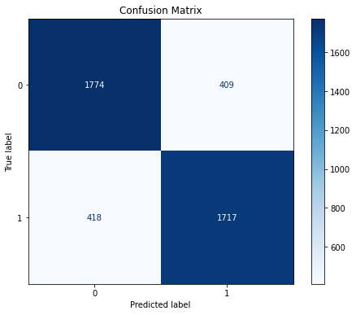

```python
params = {}
run_model(LogisticRegressionModel, X_train, y_train, X_test, y_test, params)
```

From confusion matrix we can infer accuracy: $$Accuracy = \frac{TP + TN}{TP + TN + FP + FN} = 80.8 \%$$ Here our model both performs well on test and train so we don't have overfitting nor underfitting.

## Ensemble Learning

### Random Forests

Random forests is a machine learning algorithm that builds multiple decision trees and combines their predictions to improve accuracy and reduce overfitting. It randomly selects a subset of features for each tree and uses bagging to train each tree on a different subset of the training data. The final prediction is made by aggregating the predictions of all the trees.

```python
from sklearn.ensemble import RandomForestClassifier

class RandomForestModel(ClassifierModel):
    def create_classifier(self, params):
        return RandomForestClassifier(criterion=params['criterion'], max_depth=params["max_depth"],
                                      n_estimators=params["n_estimators"])

    def set_search_params(self):
        return {
            'n_estimators': range(70, 200, 30),
            'criterion': ['entropy', 'gini'],
            'max_depth': range(5, 10),
        }
```

```
model's train accuracy:  0.928
model's test accuracy:  0.888
Best hyperparameters: {'criterion': 'gini', 'max_depth': 9, 'n_estimators': 190}
Best model's train accuracy score: 0.891
Best model's test score: 0.884
```

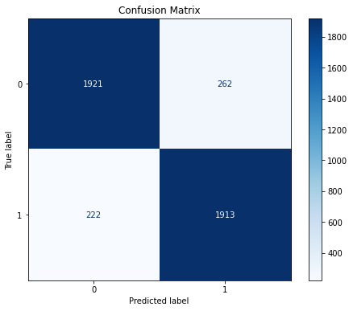

```python
params = {
        'criterion': "gini",
        'max_depth': 10,
        'n_estimators': 100,
}
run_model(RandomForestModel, X_train, y_train, X_test, y_test, params)
```

From confusion matrix we can infer accuracy: $$Accuracy = \frac{TP + TN}{TP + TN + FP + FN} = 88.8 \%$$ Here our model both performs well on test and train so we don't have overfitting nor underfitting.

I plotted the model's accuracy when we change `n_estimators` and `max_depth`. We can see both test and train accuracy increase as we increase these hyperparameters but after a while, test accuracy doesn't increase anymore which shows that our model is overfitting.

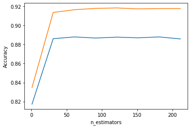

```python
test_accs = []
train_accs = []
n_estimators_interval = range(1, 230, 30)
params = {
        'criterion': 'gini',
        'max_depth': 9,
        'n_estimators': 1,
}
for i in n_estimators_interval:
    params["n_estimators"] = i
    model = RandomForestModel(X_train, y_train, params)
    test_accs.append(model.calc_accuracy(X_test, y_test))
    train_accs.append(model.get_train_accuracy())

plt.plot(n_estimators_interval, test_accs)
plt.plot(n_estimators_interval, train_accs)
plt.xlabel('n_estimators')
plt.ylabel('Accuracy')
```

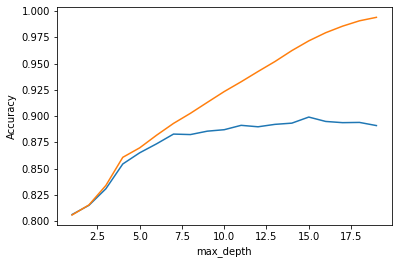

```python
test_accs = []
train_accs = []
max_depth_interval = range(1, 20)
params = {
        'criterion': 'entropy',
        'max_depth': 1,
        'n_estimators': 50,
        'min_samples_split': 2
}
for i in max_depth_interval:
    params["max_depth"] = i
    model = RandomForestModel(X_train, y_train, params)
    test_accs.append(model.calc_accuracy(X_test, y_test))
    train_accs.append(model.get_train_accuracy())
plt.plot(max_depth_interval, test_accs)
plt.plot(max_depth_interval, train_accs)
plt.xlabel('max_depth')
plt.ylabel('Accuracy')
```

#### Bias

Bias is the difference between the average prediction of our model and the correct value which we are trying to predict. A high bias can cause an algorithm to miss the relevant relations between features and target outputs (underfitting).

#### Variance

Variance is the variability of model prediction for a given data point or a value which indicates the spread of the data. A high variance can cause overfitting: modeling the random noise in the training data, rather than the intended outputs.

Random forests are an ensemble method that combines multiple decision trees to reduce variance and improve generalization but Decision Trees have more varaince and less bias because they tend to overfit with training data.

```python
from mlxtend.evaluate import bias_variance_decomp


dt_params = {
        'criterion': "entropy",
        'max_depth': 8,
        'min_samples_split': 1,
        'min_samples_leaf': 4,
}

rf_params = {
        'criterion': "gini",
        'max_depth': 9,
        'n_estimators': 100,
}

dt_model = DecisionTreeModel(X_train, y_train, dt_params)
rf_model = RandomForestModel(X_train, y_train, rf_params)

_, dt_bias, dt_var = bias_variance_decomp(dt_model.classifier,
                                                X_train.values , y_train.values,
                                                X_test.values, y_test.values,
                                                loss='mse')

_, rf_bias, rf_var = bias_variance_decomp(rf_model.classifier,
                                                X_train.values , y_train.values,
                                                X_test.values, y_test.values,
                                                loss='mse')

print(f'Decision Tree Bias:     {dt_bias:.2f}')
print(f'Decision Tree Variance: {dt_var:.2f}')
print(f'Random Forest Bias:     {rf_bias:.2f}')
print(f'Random Forest Variance: {rf_var:.2f}')
```

```
Decision Tree Bias:     0.08
Decision Tree Variance: 0.04
Random Forest Bias:     0.10
Random Forest Variance: 0.01
```

## Gradiant Boosting and XGBoost

Gradient boosting is a popular machine learning technique for building predictive models. It involves combining multiple weak models, typically decision trees, to create a strong ensemble model. The basic idea is to fit a sequence of simple models to the residuals of the previous model, with the objective of minimizing a loss function. This process continues until a stopping criterion is met, such as a maximum number of iterations or a minimum improvement in the loss function.

XGBoost (Extreme Gradient Boosting) is a specific implementation of gradient boosting that is designed to be efficient, scalable, and highly accurate. It uses a combination of techniques, such as parallel processing, tree pruning, and regularization, to optimize the training process and improve the performance of the model.

```python
from xgboost import XGBClassifier

class XGBModel(ClassifierModel):
    def create_classifier(self, params):
        return XGBClassifier(gamma=1, learning_rate=params["learning_rate"], max_depth=params["max_depth"], n_estimators=100)

    def set_search_params(self):
        return {
            'learning_rate': np.arange(0.1, 0.9, 0.05),
            'max_depth': range(3, 21, 3),
        }
```

```
model's train accuracy:  0.913
model's test accuracy:  0.891
Best hyperparameters: {'learning_rate': 0.25000000000000006, 'max_depth': 3}
Best model's train accuracy score: 0.894
Best model's test score: 0.891
```

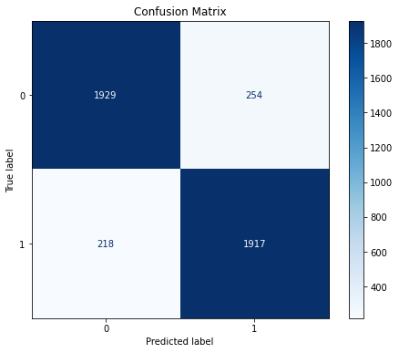

```python
params = {
    "learning_rate" : 0.1,
    "max_depth" : 5,
}
run_model(XGBModel, X_train, y_train, X_test, y_test, params)
```

From confusion matrix we can infer accuracy: $$Accuracy = \frac{TP + TN}{TP + TN + FP + FN} = 89.1 \%$$ Here our model both performs well on test and train so we don't have overfitting nor underfitting.